# NYC Building Energy Performance & Data Quality Analysis

Author

Ella Ashburn

# 1 Introduction

New York City’s building energy benchmarking disclosures provide an opportunity to examine reported energy intensity across different property types and years. Before drawing conclusions from these records, however, the data must be checked for repeated submissions, missing measurements, and unusually large values.

This project investigates the question: **How does energy performance vary across NYC buildings, and what data-quality issues could affect the reliability of energy-efficiency assessments?** It uses SQL through SQLite for data inspection and cleaning, and R for statistical summaries and visualization. The analysis covers calendar years **2022–2024** and focuses on **Site Energy Use Intensity (Site EUI)**, measured in kBtu per square foot.

The workflow begins with validation of the raw data, builds a reproducible cleaned table, explores annual and property-type patterns, and finishes with a matched-building comparison that follows the same properties over time. Site EUI is an intensity measure, not a direct test of why a building’s energy consumption changed.

**Data source:** NYC Building Energy and Water Data Disclosure for Local Law 84 (calendar years 2022–2024).

## 1.1 Reproducibility and file paths

The original analysis used a local CSV in the Downloads folder and a SQLite file named `nyc_building_energy.sqlite`. Before rendering on another computer, update the CSV path in the import chunks. The document recreates the SQLite tables as it runs.

## 1.2 Data import and initial validation

The original file contains 103,259 records and 265 columns.

After fixing the parsing issues our NYC building energy data set now contains 103,259 rows and 265 columns.

```
 2022  2023  2024
30485 33684 39090
```

The first step in checking duplicates was to identify a consistent property identifier.

## 1.3 Identifying properties and duplicate records

I checked whether each property ID appeared only once in a reporting year.

A property should normally contribute one observation per calendar year to a property-level annual comparison. The following checks identify repeated property-year combinations.

The next query counts how many property-year groups have repeated submissions.

The duplicate-frequency table distinguishes groups with two, three, or four submissions.

```
# A tibble: 4 × 3
  `Calendar Year`     n    nn
            <dbl> <int> <int>
1            2022     2   153
2            2023     2   615
3            2023     3     2
4            2023     4     1
```

I next checked whether the repeated submissions were identical across all columns.

There were no rows that were identical across every column. Repeated property-year submissions may contain equivalent energy values.

There are no completely identical rows in the original dataset.

To understand the duplicates, I compared the fields in two submissions for the same property and year.

For one example property, `vapply()` compares the first two records separately for every column and returns the names of fields that differ.

For this example, only the report generation and submission timestamps differed.

```
# A tibble: 2 × 4
  `Property ID` `Calendar Year` `Report Generation Date` Report Submission Dat…¹
          <dbl>           <dbl> <chr>                    <chr>
1       1069082            2022 05/04/2023 02:40:00 PM   05/04/2023 02:42:00 PM
2       1069082            2022 05/08/2023 03:46:00 PM   05/08/2023 03:49:00 PM
# ℹ abbreviated name: ¹`Report Submission Date`
```

The second example also differed only in the reporting timestamps.

These examples prompted a broader check for conflicting energy measurements among repeated submissions.

## 1.4 SQL database and duplicate-resolution methodology

SQLite was used to inspect submissions and perform deduplication while preserving the full original dataset.

Verify all records were transferred correctly

```
  total_records
1        103259
```

Check the number of records by year, to understand distribution

```
  Calendar Year total_buildings
1          2022           30485
2          2023           33684
3          2024           39090
```

Count repeated property-year combinations

This query counts **repeated property-year groups**, rather than the number of additional rows. In the original data there were 153 such groups in 2022 and 618 in 2023.

```
  Calendar Year repeated_properties
1          2022                 153
2          2023                 618
```

Repeated submissions could give some properties too much weight in annual summaries if each row were counted separately.

Before deduplicating, I checked whether reported EUI values changed across submissions.

A separate calculation counts **extra rows beyond the first submission**: 153 in 2022 and 622 in 2023, or 775 rows in total. The distinction matters because a few groups contain more than two submissions.

```
  Calendar Year extra_records
1          2022           153
2          2023           622
```

The next query checks for distinct EUI values within repeated property-year groups.

`COUNT(DISTINCT ...)` checks whether repeated submissions contain different Site EUI values. Some property-year groups did, so selecting an observation required a documented rule.

```
   Calendar Year Property ID record_count distinct_eui_values
1           2023     5834470            4                   3
2           2023     6802212            3                   2
3           2023    33561278            2                   2
4           2023    26528394            2                   2
5           2023    26528200            2                   2
6           2023    26119649            2                   2
7           2023    25474672            2                   2
8           2023    22895668            2                   2
9           2023    20828250            2                   2
10          2023    20775919            2                   2
```

Some properties reported different Site EUI values for the same calendar year.

```
  Property ID Calendar Year Site EUI (kBtu/ft²) Report Generation Date
1     5834470          2023                25.4 04/25/2024 01:00:17 PM
2     5834470          2023                25.4 05/01/2024 05:20:41 PM
3     5834470          2023                25.6 05/01/2024 11:48:14 PM
4     5834470          2023                26.7 08/01/2024 04:48:15 PM
  Report Submission Date
1 04/25/2024 01:06:17 PM
2 05/01/2024 05:21:25 PM
3 05/01/2024 11:49:12 PM
4 08/01/2024 04:50:00 PM
```

```
  Calendar Year total_records missing_dates
1          2022         30485             0
2          2023         33684             0
3          2024         39090         39090
```

The timestamp strings were converted to a format that sorts chronologically.

Submission timestamps were converted from month/day/year and 12-hour clock notation into a sortable year-month-day and 24-hour format.

I then ranked submissions by date within each property-year group.

`ROW_NUMBER()` ranks submissions within each property-year group. `PARTITION BY` restarts the ranking for each property and year; descending timestamp order places the latest submission first.

The ranked records were used to create a cleaned SQL table.

The cleaned table retains one record per property-year combination, selecting the latest available submission. The original `buildings` table remains available for auditing. Re-running this chunk rebuilds `buildings_clean`.

**Method note:** The ranking is based on the latest reported submission timestamp. Where dates are missing or tied, the selected row may depend on the available ordering information. The cleaned table is appropriate for this exploratory analysis, but these cases are a limitation.

The resulting cleaned table contains **102,484 records**, 775 fewer than the original.

```
  cleaned_records
1          102484
```

The cleaned table contains 102,484 records, 775 fewer than the original.

A final check tests whether any repeated property-year groups remain.

```
[1] Property ID   Calendar Year record_count
<0 rows> (or 0-length row.names)
```

No repeated property-year groups remain after deduplication.

## 1.5 Missing and invalid Site EUI values

Before statistical analysis, I checked whether Site EUI was absent, blank, nonnumeric, or negative. These cases are not interchangeable in SQLite.

The initial SQL check showed no NULL values in the Site EUI field, so I investigated other missing-value representations.

The next query checks for blank strings and missing-value labels.

The Site EUI field contains no SQL NULL values or empty strings in the cleaned table.

The next check looks for nonnumeric Site EUI entries.

An explicit `Not Available` string must be excluded before numerical calculations. In SQLite, casting a nonnumeric string to `REAL` can produce zero rather than a missing value.

Negative Site EUI values are not physically meaningful in this context, while `Not Available` indicates an unavailable measurement.

I checked how these invalid or unavailable values were distributed across reporting years.

The largest count of unavailable Site EUI records occurred in 2024. These values are retained in the cleaned database but excluded from valid-EUI calculations.

```
  Calendar Year total_records unavailable_eui negative_eui
1          2022         30332            1570            1
2          2023         33062            2728            1
3          2024         39090            8513            2
```

Unavailable EUI values appear in each year, with the highest count in 2024.

Filtering out unavailable and negative EUI leaves 28,761 valid observations in 2022, 30,333 in 2023, and 30,575 in 2024.

```
  Calendar Year valid_eui_records
1          2022             28761
2          2023             30333
3          2024             30575
```

Unavailable and negative values are excluded from numeric EUI summaries, but retained in the cleaned database for auditing.

With a defined valid-EUI subset, the analysis turns to differences across years.

## 1.6 Annual energy-intensity analysis

Annual means are highly sensitive to extreme values, so the next steps examine the distribution before drawing conclusions.

```
  Calendar Year avg_site_eui
1          2022       711.08
2          2023     15018.12
3          2024      5137.51
```

The 2023 mean of 15,018.12 kBtu/ft² is unusually high, suggesting strong influence from extreme observations.

I examined the largest reported Site EUI values to understand the skew.

This query sorts valid Site EUI numerically rather than alphabetically. The most extreme values are far above typical building energy intensities and warrant caution.

```
   Calendar Year Property ID       property_type site_eui
1           2023     4038924 Multifamily Housing 14931000
2           2022    25764297 Multifamily Housing 14708000
3           2023    25764297 Multifamily Housing 13417900
4           2023     4038925 Multifamily Housing 12866090
5           2023     4038923 Multifamily Housing 12514460
6           2024    10856048 Multifamily Housing 11285380
7           2023    10856048 Multifamily Housing 11082470
8           2023    33602833 Multifamily Housing 10924100
9           2023    33898146 Multifamily Housing 10599000
10          2023    33602969 Multifamily Housing 10127000
```

Some reported Site EUI values reach into the millions of kBtu/ft².

These extremely high intensities could reflect reporting or unit issues, although the data alone do not establish the cause.

I checked whether the extreme observations were concentrated in particular property types.

```
  Property ID              Property Name       property_type site_eui
1     4038924 Orsid - 84-10 153rd Avenue Multifamily Housing 14931000
```

The most extreme observation was classified as multifamily housing, where a value this high must be investigated. This does explain however why the averages were so high. It can be seen a small number of extreme values can drastically increase the mean.

I compared annual means and medians to assess sensitivity to extreme values.

For annual comparisons, medians provide a more robust summary than means when the dataset contains extreme high values.

```
  year site_eui
1 2022     76.0
2 2023     69.3
3 2024     69.5
```

The medians were far lower than the means, consistent with a small number of unusually high observations skewing the mean upward. In order to decide what to do with the extreme values I will first try an understand their distribution.

The next calculation examines the upper end of the EUI distribution.

The 50th, 90th, and 99th percentiles describe the center and upper tail of the distribution.

```
  year site_eui.50% site_eui.90% site_eui.99%
1 2022       76.000      125.700      336.880
2 2023       69.300      119.900      470.372
3 2024       69.500      122.500      455.332
```

The percentile plot helps show why the median is more informative than the mean for this dataset.

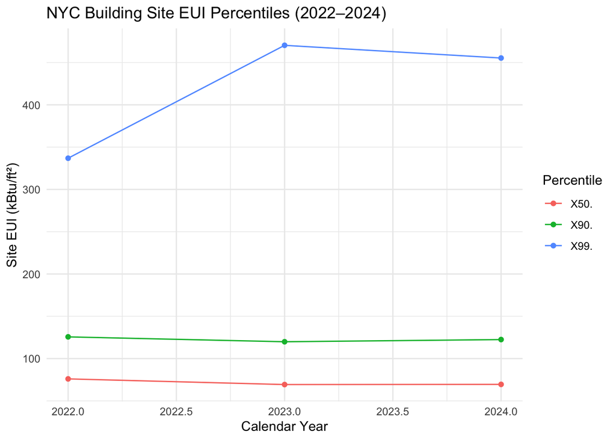

**Interpretation:** Extreme high EUI observations substantially affect the annual means. Medians and upper percentiles are therefore presented alongside the mean rather than discarding unusual values without verification.

The upper-tail results support retaining the flagged records for review while using medians for the main descriptive comparisons.

I used 1,000 kBtu/ft² as an exploratory threshold to count unusually high reports.

## 1.7 Extreme values and property-type comparisons

The threshold of 1,000 kBtu/ft² is an **exploratory flag**, not an official error cutoff. Flagged values are not automatically removed.

The next calculation expresses these counts as percentages of records.

```
  year total_records extreme_records percentage
1 2022         30332              67       0.22
2 2023         33062             183       0.55
3 2024         39090             160       0.41
```

Less than 1% of records in each year exceeded the exploratory threshold; 2023 had the highest share at approximately 0.55%.

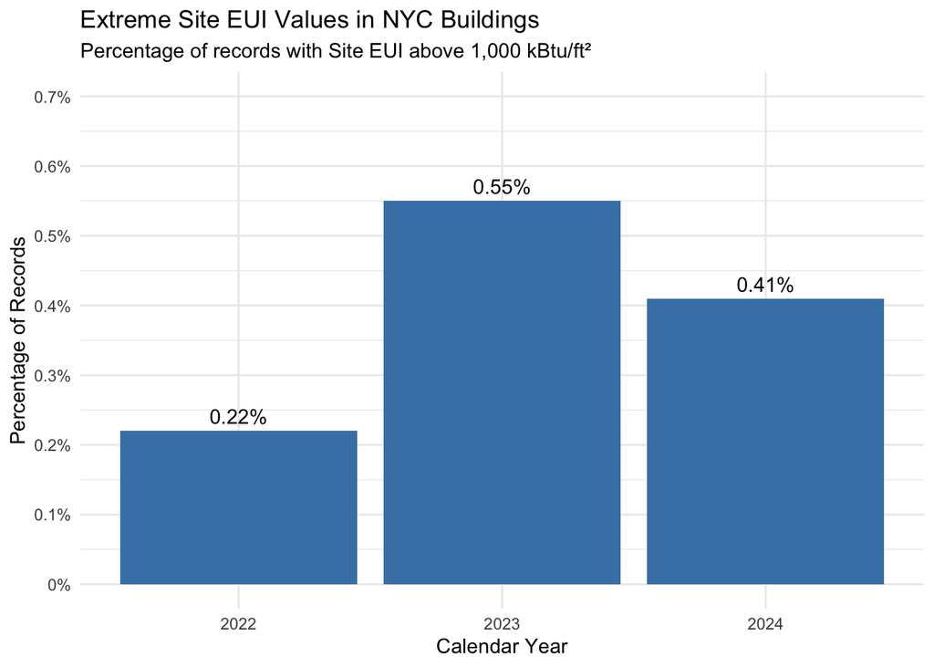

Fewer than 1% of records exceeded 1,000 kBtu/ft² in each year; the largest share was in 2023 (about 0.55%), compared with 0.22% in 2022 and 0.41% in 2024. Although these observations were uncommon, their unusually high values substantially influenced the annual mean Site EUI. These records were retained in the cleaned dataset for further investigation, while median values were used to describe typical energy performance.

I next compared flagged observations across property types.

Multifamily housing accounted for approximately 53.4% of the 410 flagged observations, but it also represents a large share of the data set. (68,103). That means having the highest number of extreme records doesn’t necessarily mean multifamily buildings are the most likely to report extreme EUI.

I therefore calculated flagged-record rates within each category.

Raw counts of extreme observations can be misleading when categories differ greatly in size. The within-category percentage offers a fairer comparison.

```
                    property_type total_records extreme_records
1             Multifamily Housing         68103             219
2              College/University          1316              29
3                    Retail Store          1027              21
4                          Office          7536              16
5              Other - Recreation           707              15
6                             Zoo           449              13
7  Manufacturing/Industrial Plant          1262              13
8                      Strip Mall           420               8
9                      Laboratory           180               8
10                          Other           295               7
   percentage_extreme
1                0.32
2                2.20
3                2.04
4                0.21
5                2.12
6                2.90
7                1.03
8                1.90
9                4.44
10               2.37
```

Laboratories had a relatively high proportion of flagged observations. Their energy-intensive operations may help explain some high values.

I calculated annual median EUI for each self-selected property type.

Building types are identified using the self-selected primary property-type field. The analysis computes a separate median for each type and calendar year.

For a readable comparison, I selected five major property categories.

```
    year       property_type site_eui
18  2022  College/University    88.90
19  2023  College/University    70.10
20  2024  College/University    72.20
62  2022               Hotel    90.00
63  2023               Hotel    84.80
64  2024               Hotel    86.45
71  2022         K-12 School    70.90
72  2023         K-12 School    59.60
73  2024         K-12 School    59.50
98  2022 Multifamily Housing    78.10
99  2023 Multifamily Housing    71.70
100 2024 Multifamily Housing    71.80
107 2022              Office    61.40
108 2023              Office    56.50
109 2024              Office    58.30
```

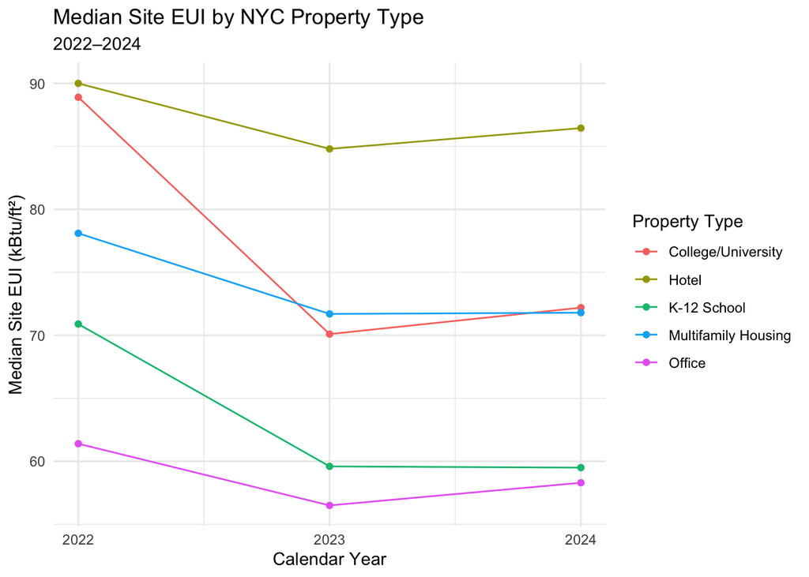

Sample sizes were added because medians based on fewer observations require more caution.

The next chunk calculates the number of valid records per category and year.

The number of valid observations contributing to each median is calculated so readers can judge how much data supports each comparison.

In the bubble-line chart, each point is an annual median and bubble area represents the number of valid observations.

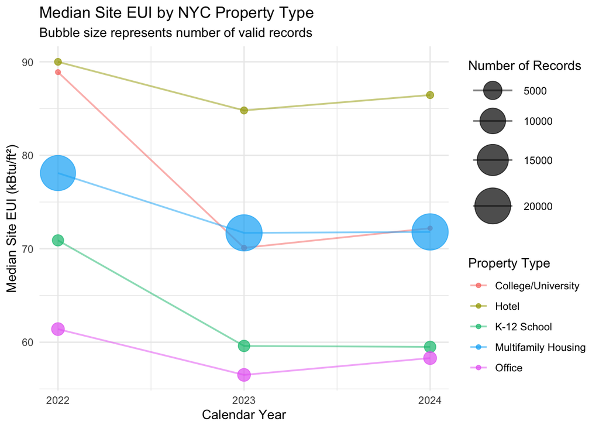

The matched-building analysis begins by identifying properties with valid reports in all three years.

## 1.8 Matched-building analysis, 2022–2024

Annual property-type medians may describe different sets of buildings. A matched-building analysis instead follows the same property IDs across all three years.

```
  buildings_with_valid_eui
1                    21708
```

`pivot_wider()` places each property’s annual EUI into separate columns; `drop_na()` retains only properties with valid EUI in 2022, 2023, and 2024. This produces **21,708 matched properties**.

```
[1] 21708
```

```
# A tibble: 10 × 4
   property_id `2022` `2023` `2024`
         <dbl>  <dbl>  <dbl>  <dbl>
 1        7365   47.6   49.8   54.9
 2        8139   67.8   77.2   87.6
 3        8604   55.8   54.3   59.5
 4        8841   82     80.3   82.4
 5       11809   88.1   84.9   79.7
 6       28400  248.   235.   377
 7       28402  384.   357.   382.
 8       28404  238.   222.   245.
 9     1045358   71.8   66.5   61.3
10     1052478   46.3   42.2   92.8
```

For each matched property, I calculated absolute and percentage changes between 2022 and 2024.

Absolute EUI change is 2024 minus 2022. Percentage change uses 2022 as the baseline; `na_if(..., 0)` avoids division by zero.

Among 21,708 matched buildings, **14,621 decreased**, **6,975 increased**, and **112 were unchanged**. The median building-level change was **−4.1 kBtu/ft²**, and the median percentage change was approximately **−5.99%**.

```
# A tibble: 1 × 6
  total_buildings decreased increased unchanged median_change
            <int>     <int>     <int>     <int>         <dbl>
1           21708     14621      6975       112         -4.10
# ℹ 1 more variable: median_percent_change <dbl>
```

Most matched properties reported lower Site EUI in 2024 than in 2022.

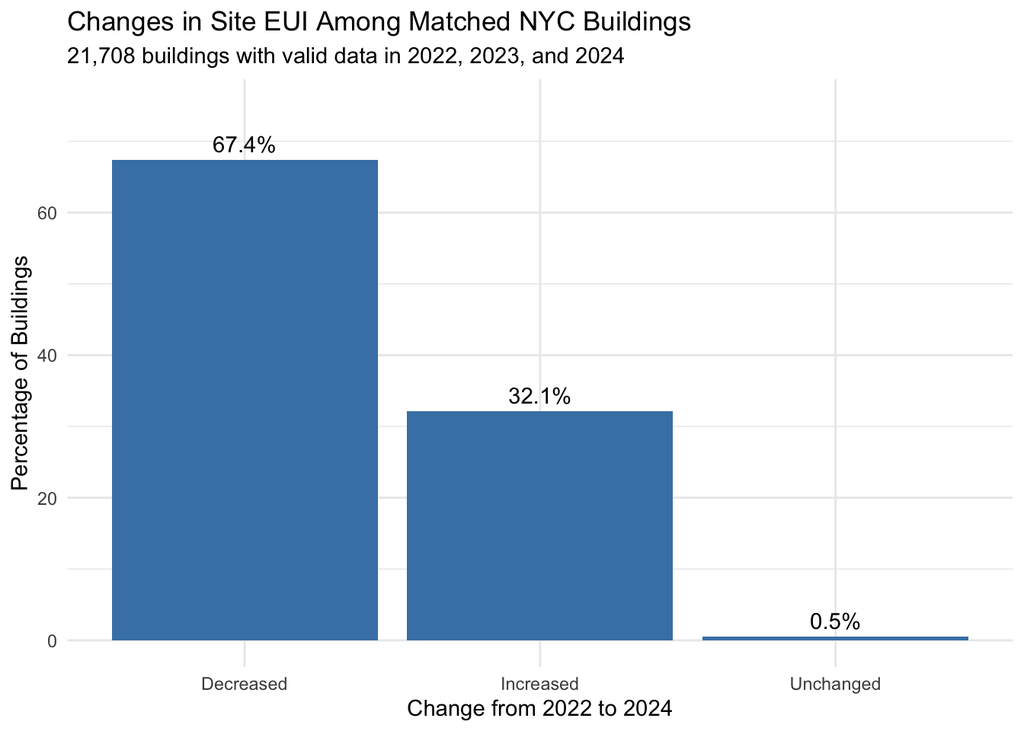

**Interpretation:** About 67.4% of matched properties reported lower EUI in 2024 than in 2022; about 32.1% reported higher EUI. The median building-level percentage change was approximately −6%. This is a descriptive finding, not evidence of a particular intervention.

## 1.9 Differences across building types

Each matched building is assigned its **2022 self-selected property type** for a consistent baseline classification. A property’s actual use may have changed later.

Only categories with at least 100 matched buildings are plotted. This is a descriptive sample-size threshold, not a statistical significance test.

```
# A tibble: 17 × 4
   property_type               buildings median_percent_change percent_decreased
   <chr>                           <int>                 <dbl>             <dbl>
 1 K-12 School                      1547                -16.1               81.8
 2 Non-Refrigerated Warehouse        307                 -9.80              66.8
 3 Self-Storage Facility             160                 -9.62              68.1
 4 Mixed Use Property                143                 -8.36              72.0
 5 Repair Services (Vehicle, …       116                 -8.14              67.2
 6 College/University                182                 -8.11              59.3
 7 Manufacturing/Industrial P…       246                 -6.62              63.0
 8 Residence Hall/Dormitory          151                 -5.96              62.3
 9 Multifamily Housing             14405                 -5.57              68.4
10 Distribution Center               128                 -5.42              57.8
11 Office                           1708                 -5.42              63.2
12 Other - Recreation                194                 -4.89              55.2
13 Pre-school/Daycare                107                 -3.95              57.0
14 Retail Store                      201                 -3.13              56.2
15 Worship Facility                  116                 -3.10              56.0
16 Hotel                             384                 -1.15              52.1
17 Parking                           117                  2.05              44.4
```

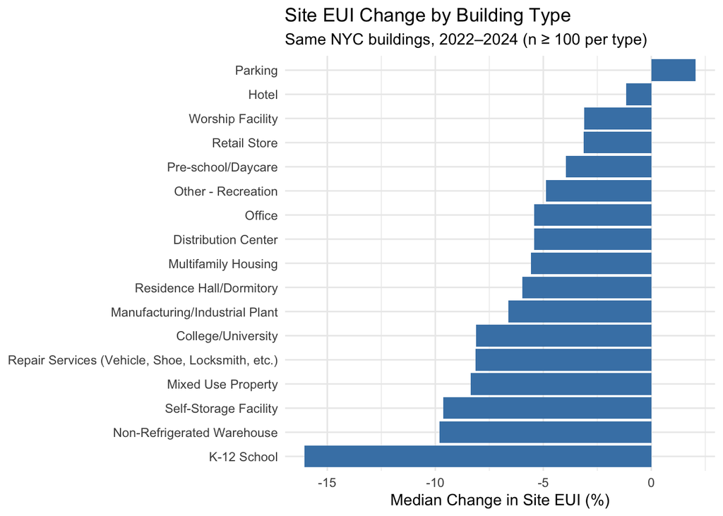

Among 1,547 matched K-12 schools, the annual median Site EUI was **72.0 in 2022**, **60.4 in 2023**, and **60.5 in 2024**.

```
# A tibble: 1 × 3
  median_2022 median_2023 median_2024
        <dbl>       <dbl>       <dbl>
1          72        60.4        60.5
```

The median Site EUI for matched schools fell sharply in 2022–2023 and remained almost unchanged in 2023–2024.

Calculating each school’s year-to-year percentage change first gives median changes of approximately **−15.70% (2022–2023)** and **−0.11% (2023–2024)**.

```
# A tibble: 1 × 2
  change_2022_2023 change_2023_2024
             <dbl>            <dbl>
1            -15.7           -0.113
```

I then checked whether the same timing appeared in other property categories.

Several other property types also show a first-period decline followed by smaller changes or increases in the second period. This suggests the school pattern is part of a broader descriptive trend, although the causes cannot be identified from these data alone.

```
# A tibble: 17 × 4
   property_type                             buildings change_22_23 change_23_24
   <chr>                                         <int>        <dbl>        <dbl>
 1 K-12 School                                    1547       -15.7        -0.113
 2 Repair Services (Vehicle, Shoe, Locksmit…       116       -15.1         5.97
 3 Self-Storage Facility                           160       -14.8         4.40
 4 Other - Recreation                              194       -12.7         1.15
 5 Non-Refrigerated Warehouse                      307       -11.2         1.59
 6 Distribution Center                             128        -9.19        1.32
 7 Residence Hall/Dormitory                        151        -8.29        3.18
 8 Pre-school/Daycare                              107        -7.51        2.71
 9 Office                                         1708        -7.27        2.03
10 Multifamily Housing                           14405        -7.09        1.66
11 Manufacturing/Industrial Plant                  246        -6.98        1.10
12 Mixed Use Property                              143        -6.92        1.33
13 College/University                              182        -6.36       -1.61
14 Retail Store                                    201        -6.04        2.24
15 Worship Facility                                116        -5.89        1.05
16 Hotel                                           384        -3.00        2.86
17 Parking                                         117        -1.49        3.77
```

**Interpretation:** The pronounced 2022–2023 decrease was not limited to schools. A possible explanation is changing occupancy or operations following the COVID-19 pandemic, but the available data do not establish a cause. Weather, reporting practices, and building operations could also contribute.

Several property types show a large median decline in 2022–2023 followed by smaller changes in 2023–2024.

The widespread decrease in Site EUI between 2022 and 2023 may partly reflect changes in building occupancy and operations following the COVID-19 pandemic. However, differences in weather conditions, energy use, and reporting practices may also have contributed. Further analysis would be needed to determine what drove these changes.

# 2 Discussion and limitations

The investigation identified several data-quality concerns that matter for energy benchmarking. Repeated property year submissions required a consistent selection rule, `Not Available` values could not be treated as valid zero measurements, and a small number of exceptionally high EUI records strongly influenced means. These findings support using descriptive statistics and documenting exclusions.

The analysis has important limitations. Site EUI does not account for weather in these calculations, building occupancy and operating hours were not controlled for, and self-reported property classifications may change. Changes in EUI should not be attributed solely to efficiency improvements or pandemic related occupancy without additional evidence.

# 3 Conclusion

This project demonstrates how data validation affects the reliability of environmental performance comparisons. Starting with 103,259 raw records, the workflow created a cleaned dataset of 102,484 property-year records and identified 21,708 properties with valid Site EUI in all three years. The matched analysis found a median building-level Site EUI change of approximately −5.99% from 2022 to 2024, with substantial variation across property types.

The main takeaway is that building energy benchmarking data can identify patterns and potential priorities for investigation, but careful treatment of duplicate submissions, missing values, and outliers is necessary before interpreting those patterns.